# Explantory part-2

## Dataset Overview

The data consisted of Loan Amount, interest Rate and other attributes of approximately 1,13,937 Loan related records. The Loan data specfically originated after July 2009. twenty five data points were removed from the analysis due to inconsistencies or missing information.

## What affects the borrower’s APR or interest rate?

CreditGrade & ProsperRating variables are more impacting on barrower interest rate

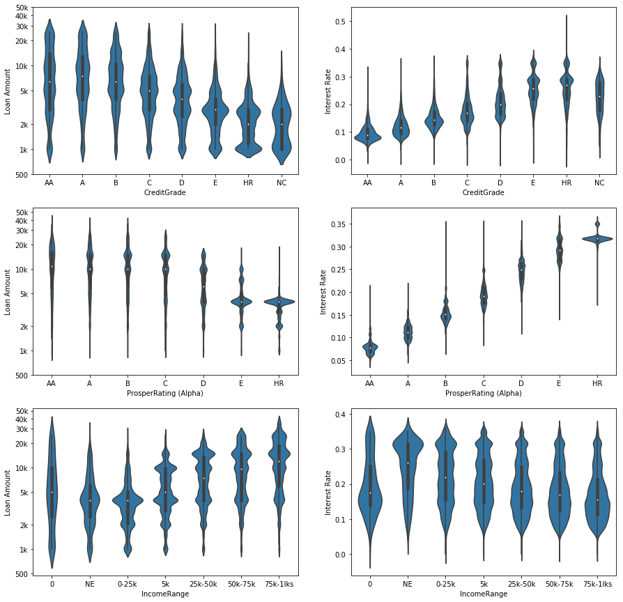

```python
# plot the categorical variables against loan Amount,Interest Rate and carat again, this time
# with full data and variable transforms
fig, ax = plt.subplots(ncols = 2, nrows = 3 , figsize = [15,15])
default_color = sb.color_palette()[0]
categoric_vars =['CreditGrade','ProsperRating (Alpha)','IncomeRange']

for i in range(len(categoric_vars)):
    var = categoric_vars[i]
    sb.violinplot(data = Loans, x = var, y = 'Log_LoanAmount', ax = ax[i,0],
               color = default_color)
    ax[i,0].set_yticks(log_trans(np.array([500, 1e3, 2e3, 5e3, 1e4, 2e4,3e4,4e4,5e4])))
    ax[i,0].set_yticklabels([500, '1k', '2k', '5k', '10k', '20k','30k','40k','50k'])
    if var =="IncomeRange":
        ax[i,0].set_xticklabels(['0', 'NE', '0-25k', '5k', '25k-50k', '50k-75k','75k-1lks','>1lks'])

    ax[i,0].set_ylabel('Loan Amount')
    sb.violinplot(data = Loans, x = var, y = 'BorrowerRate', ax = ax[i,1],
               color = default_color)
    ax[i,1].set_ylabel('Interest Rate')
    if var =="IncomeRange":
        ax[i,1].set_xticklabels(['0', 'NE', '0-25k', '5k', '25k-50k', '50k-75k','75k-1lks','>1lks'])
        plt.show()
```

## Are there differences between loans depending on how large the original loan amount was?

The Large amount of loans depending on the Income range Amount . As per diagaram there are few barrowers is buying more than 30 K due the income range amout is more than 1Laks which they shown in Bank.

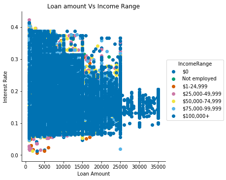

```python
figsize = [12,6]
g = sb.FacetGrid(data = Loans, hue = 'IncomeRange', size = 5,
                 palette = 'colorblind')
g.map(plt.scatter, 'LoanOriginalAmount', 'BorrowerAPR')
g.set_xlabels('Loan Amount')
g.set_ylabels('Interest Rate');
g.add_legend();
plt.title('Loan amount Vs Income Range')
plt.show()
```

## Overall Loan Status statistics

Current loans processing is higher than other loan status as per diagaram.Second most highest borrowers count is "Completed"one.

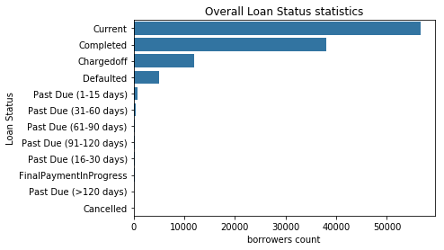

```python
# lets review the loan status count overview here .
base_color = sb.color_palette()[0]
cat_order = Loans['LoanStatus'].value_counts().index
sb.countplot(data = Loans, y= 'LoanStatus', color = base_color, order = cat_order)
#plt.xticks(rotation = 90);
plt.ylabel('Loan Status')
plt.xlabel('borrowers count');
plt.title('Overall Loan Status statistics');
```

## Purpose of the loan overview statistics

1. Debt Consolidation category is very huge acccording the other purpose of the loan.

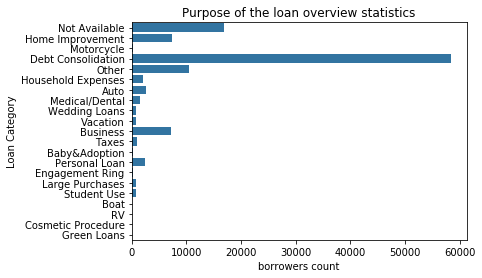

```python
# let's plot the purpose the loan distribution count list.
base_color = sb.color_palette()[0]
list_order=Loans['category'].value_counts().index
sb.countplot(data = Loans, y= 'category', color = base_color)
plt.ylabel('Loan Category')
plt.xlabel('borrowers count');
plt.title('Purpose of the loan overview statistics')
plt.show()
```

## Credit card Rating Vs Loan Status

There are many good crediter loan in open state comperately other rating borrowers.

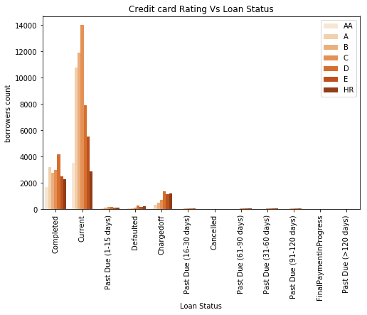

```python
#To find loan status count based on Prosper Ratings.
plt.figure(figsize = [8, 5])
sb.countplot(data = Loans, x = 'LoanStatus', hue = 'ProsperRating (Alpha)', palette = 'Oranges')
plt.xticks(rotation=90)
plt.legend(loc = 1, ncol = 1)
plt.xlabel('Loan Status')
plt.ylabel('borrowers count');
plt.title('Credit card Rating Vs Loan Status');
```

## Loan Status based on Term overview

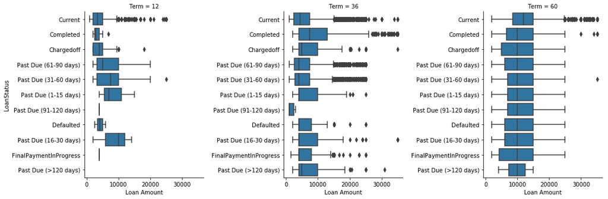

```python
g = sb.FacetGrid(data = Loans, col = 'Term', size = 5,aspect =1)
g.map(sb.boxplot, 'LoanOriginalAmount', 'LoanStatus')
g.set_xlabels('Loan Amount')
g.set_ylabels('LoanStatus');
plt.show();
```

## Unsuccessful Loan completion overview

There are many unsccesfull loan activies happening on prosper rating/loan stastus overview.

[figure not shown]

```python
Loans_filter = Loans.query('LoanStatus not in["Completed","Current"]')

fig, ax = plt.subplots(ncols = 2, figsize = [12,6])

sb.pointplot(data = Loans_filter, x = 'CreditGrade', y = 'LoanOriginalAmount', hue = 'LoanStatus',
             palette = 'Greens', linestyles = '', dodge = 0.4, ax = ax[0])
ax[0].set_title('Unsuccssfull Loan completion overview')
ax[0].set_ylabel('Loan Amount')
ax[0].set_xlabel('Credit Grade')
ax[0].set_yticks([2e3, 4e3, 6e3, 8e3,1e4,12e3,14e3,16e3])
ax[0].set_yticklabels(['2k','4k','6k', '8k', '10k','12k','14k','16k'])
ax[0].set_xticklabels([],minor = True)

sb.pointplot(data = Loans_filter, x = 'ProsperRating (Alpha)', y = 'LoanOriginalAmount', hue = 'LoanStatus',
             palette = 'Greens', linestyles = '', dodge = 0.4, ax = ax[1])
ax[1].set_title('Unsuccssfull Loan completion overview')
ax[1].set_ylabel('Loan Amount')
ax[1].set_xlabel('Proper Ratings')
ax[1].set_yticks([2e3, 4e3, 6e3,8e3,1e4,12e3,14e3,16e3,18e3,20e3])
ax[1].set_yticklabels(['2k','4k', '6k', '8k','10k','12k','14k','14k','18k','20k'])
ax[1].set_xticklabels([],minor = True)


plt.show();
```